# Correlation of AQI and Weather in Los Angeles County, California

https://github.com/sarah-kear/KearLaCroix_ENV872_EDA_FinalProject

Sarah Kear and Cole LaCroix

April 30, 2024

# 1 List of Tables

- Figure 5.1: Table Dataset Structure Table
- Figure 7.1: Mann-Kendall Test Results

# 2 List of Figures

- Figure 6.1: Los Angeles County Monthly AQI from 2010 to 2022
- Figure 6.2: Los Angeles County Monthly Minimum and Maximum Temperature from 2010 to 2022
- Figure 6.3: Los Angeles County Monthly Average Wind Speed from 2010 to 2022
- Figure 6.4: Los Angeles County Monthly Precipitation from 2010 to 2022
- Figure 7.1: Los Angeles County AQI Values Time Series Decomposed Components
- Figure 7.2: Los Angeles County Daily AQI Time Series Nonseasonal Data
- Figure 7.3: Daily AQI Value vs Maximum Temperature
- Figure 7.4: Daily AQI Value vs Minimum Temperature
- Figure 7.5: Daily AQI Value vs Average Wind Speed
- Figure 7.6: Daily AQI Value vs Precipitation

# 3 Introduction/Rationale

There is human health outcomes that are directly impacted by AQI.

# 4 Research Questions

1. The daily and monthly AQI values in Los Angeles County correlated with seasonality?
2. What is the correlation between AQI and different weather phenomena in Los Angeles County?

# 5 Data Wrangling

The daily AQI values were pulled from the Environmental Protection Agency’s (EPA) AirNow dataset. The weather data was pulled from National Oceanic Atmospheric Administration (NOAA). Both datasets provided fairly complete daily data from January 1, 2010 to December 31, 2022. The datasets were cleaned and then combined to include the Data of data collection and the six values used for time series analysis and generalized linear models.

In order to conduct time series analysis on the daily AQI values, we conducted linear interpolation to fill any missing daily AQI values. We used linear interpolation as it creates an average, and best fits AQI’s daily gradual change.

Table 5.1: Table Dataset Structure Table

| Column | Description |
| --- | --- |
| Date | Date of Collection |
| Precipitation | Daily Total Precipitation |
| Temp.Max | Daily Maximum Temperature |
| Temp.Min | Daily Minimum Temperature |
| Avg.Wind | Average Wind Speed |
| DAILY_AQI_VALUE | Daily Air Quality Index (AQI) Value |

# 6 Exploratory Analysis

Both Stations, for AQI and weather data, are located in the city center of Los Angeles. For exploratory analysis, we created a map which differentiated where both stations are located.Below is a map illustrating the locations of both AQI and weather stations utilized in this study. Both are located in Los Angeles County.

[interactive chart not shown]

We then created graphs to illustrate the average monthly AQI values, maximum and minimum temperature, average wind speed, and precipitation. Through exploratory analysis, we found that average AQI, minimum and maximum temperature, and average wind speed slightly increased between 2010 and 2022.

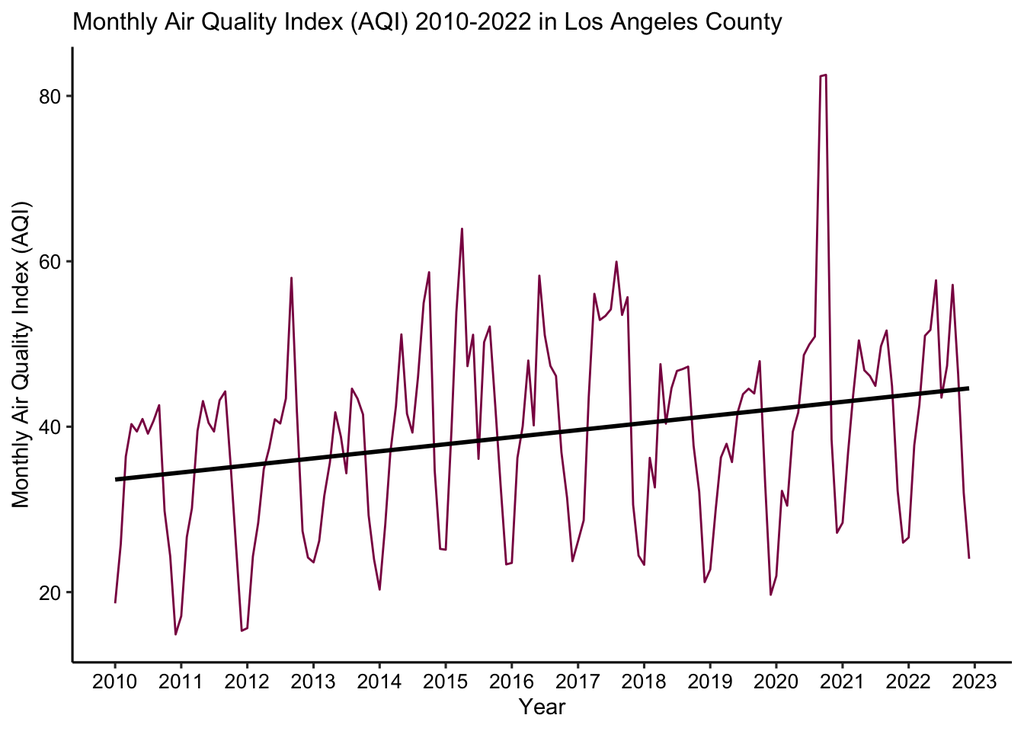

Figure 6.1: Los Angeles County Monthly AQI from 2010 to 2022

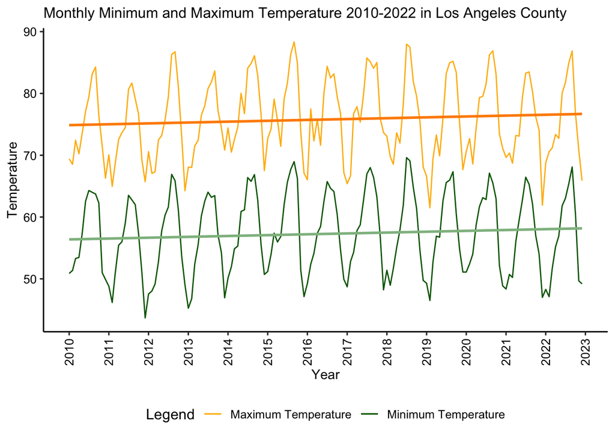

Figure 6.2: Los Angeles County Monthly Minimum and Maximum Temperature from 2010 to 2022

[figure not shown]

Figure 6.3: Los Angeles County Monthly Average Wind Speed

In comparison, monthly average precipitation have a slight decrease between 2010 and 2022. With the varying changes in the different weather phenomena – temperature, wind speed, and precipitation – we found it critical to understand how these phenomena factor into the daily AQI values.

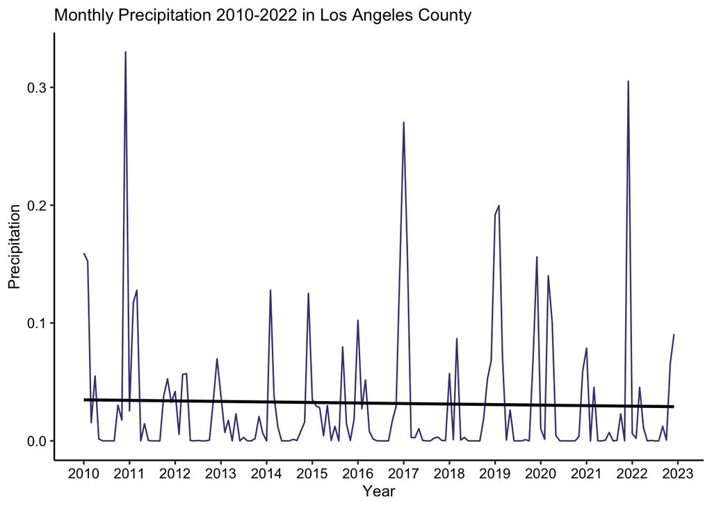

Figure 6.4: Los Angeles County Monthly Precipitation from 2010 to 2022

# 7 Analysis

The analysis we conducted was to first determine the seasonality of daily AQI values, and then to run a regression analysis to determine which weather phenomena is correlated to daily AQI values.

## 7.1 Time Series Analysis

In order to determine the effects of weather on daily AQI values, we first decomposed the Daily AQI values to gather and analyze the seasonal, trend, and remainder components of the data. The following Figure illustrates the decomposed Daily AQI value over time.

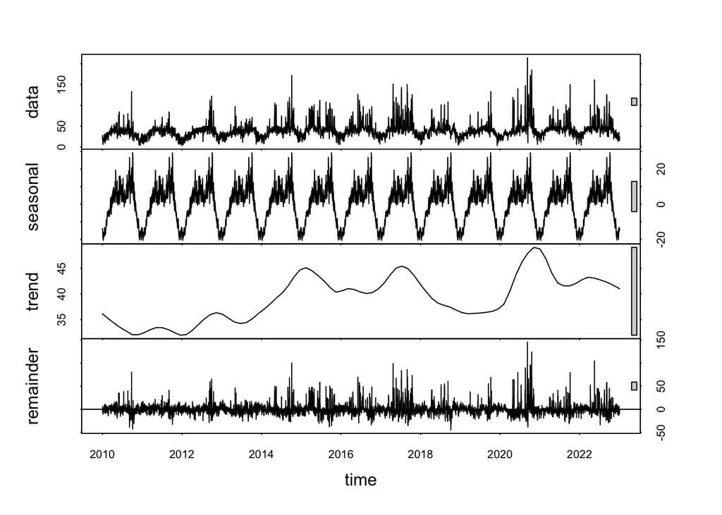

Figure 7.1: Los Angeles County AQI Values Time Series Decomposed Components

I then separated the trend and remainder data and added both together to great non-seasonal AQI values in order to determine how AQI value has changed through out 2010 to 2022 without seasonality and to use when running the generalized linear models.To further analyze the non-seasonal AQI values, we reran the non-seasonal AQI values through the time series function to statistically analyze the trend, using the Mann-Kendall test. As displayed below, The p-value is less than 0.05. We are able to reject the null hypothesis, there is a trend present in the non-seasonal AQI values. The non-seasonal time series produces a tau value of 0.177, indicating there is an increasing trend in the non-seasonal AQI values.

Table 7.1: Mann-Kendall Test Results

| Components | Value |
| --- | --- |
| tau | 0.177 |
| 2-sided pvalue | =< 2.22e-16 |

Lastly, we plotted the non-seasonal AQI Values to illustrate the increasing trend between 2010 and 2022.

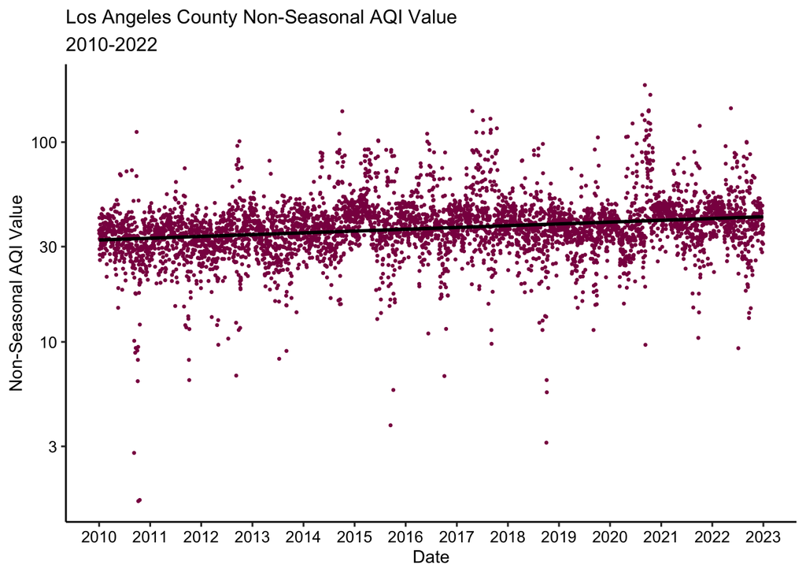

Figure 7.2: Los Angeles County Daily AQI Time Series Nonseasonal Data

## 7.2 Generalized Linear Model

|  | *Dependent variable:* |
| --- | --- |
|  | Daily AQI Value |
| Maximum Temperature | 0.991*** |
|  | (0.036) |
| Minimum Temperature | 0.247*** |
|  | (0.043) |
| Average Wind Speed | 3.189*** |
|  | (0.264) |
| Precipitation | -2.949** |
|  | (1.273) |
| Constant | -54.969*** |
|  | (1.985) |
| Observations | 4,725 |
| R<sup>2</sup> | 0.337 |
| Adjusted R<sup>2</sup> | 0.336 |
| Residual Std. Error | 14.528 (df = 4720) |
| F Statistic | 599.948*** (df = 4; 4720) |
| *Note:* | p<0.1; p<0.05; p<0.01 |

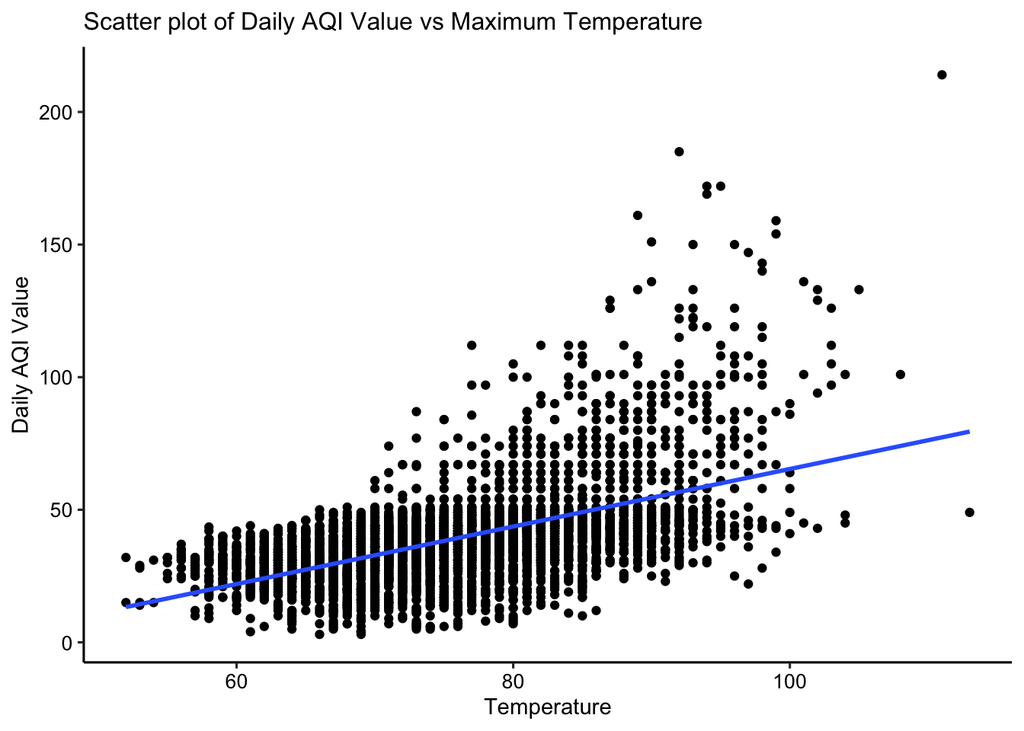

Figure 7.3: Daily AQI Value vs Maximum Temperature

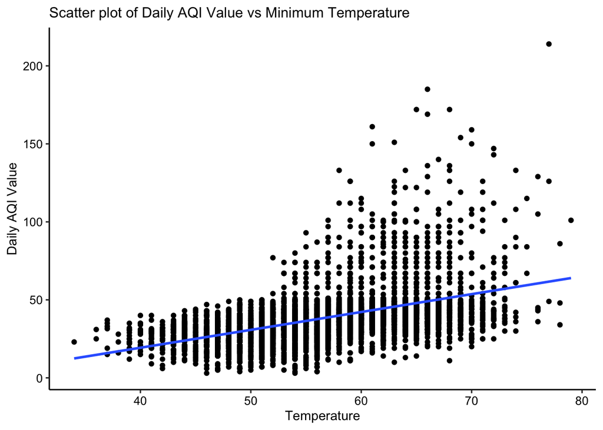

Figure 7.4: Daily AQI Value vs Minimum Temperature

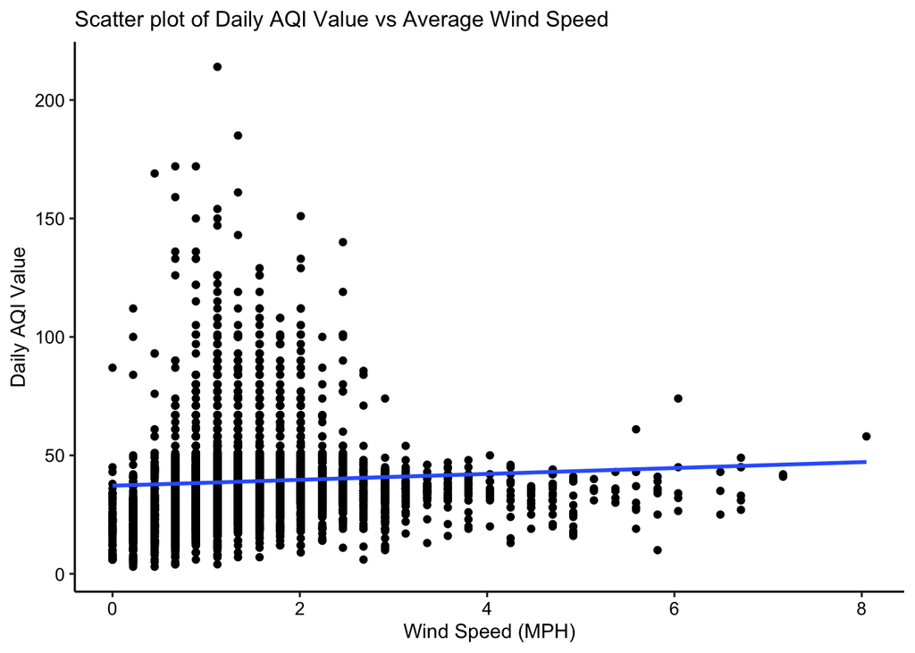

Figure 7.5: Daily AQI Value vs Average Wind Speed

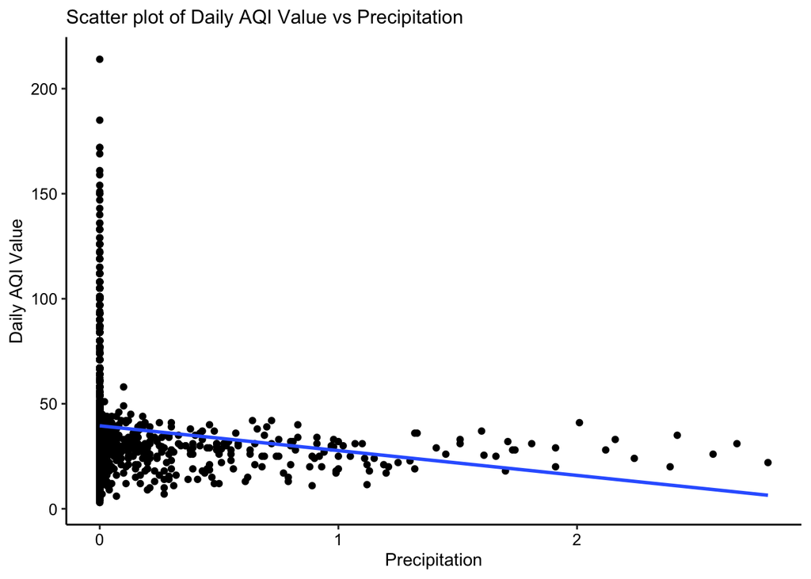

Figure 7.6: Daily AQI Value vs Precipitation

# 8 Summary and Conclusions

# 9 References